# Disease mapping with spatial CAR models

NIMBLE provides the ability to specify and fit conditional autoregressive (CAR) models, both intrinsic and proper models.

Here we’ll use an intrinsic CAR (ICAR) model for disease mapping. We’ll illustrate with data on hospital admissions due to respiratory disease in 2010 from the 134 Intermediate Geographies (IG) north of the river Clyde in the Greater Glasgow and Clyde health board. The data are available in the `CARBayesdata` package and can be transformed into the neighborhood information needed by NIMBLE using functions from the `spdep` package. In particular, we need to provide vectors indicating which regions are neighbors of which other regions (`adj`), the weights for each pair of neighbors (`weights`), and the number of neighbors for each region (`num`).

As usual, the mean of the Poisson counts includes an offset for the expected count. We’ll also include a covariate, the percentage of people defined to be income deprived in each spatial region.

```r
library(nimble, warn.conflicts = FALSE)
library(CARBayesdata, quietly = TRUE)
library(sp, quietly = TRUE)
library(spdep, quietly = TRUE)
data(GGHB.IZ)
data(respiratorydata)
```

We handle the spatial analysis here with `nb2WB` from the package `spdep`.

```r
respiratorydata_spatial <- merge(x = GGHB.IZ, y = respiratorydata, by = "IZ", all.x = FALSE)
W.nb <- poly2nb(respiratorydata_spatial, row.names =  rownames(respiratorydata_spatial))
## Determine neighborhood/adjacency information needed for neighborhood-based CAR model
nbInfo <- nb2WB(W.nb)

# A vector of indices indicating which regions are neighbors of which.
nbInfo$adj
```

```
##   [1]   2   3   5  87  91  93   1   3  91 113   1   2   5  11 113   6   7  10
##  [19]  98 101 105 106   1   3   9  11  19  87  90 104 109   4  10  12 105 108
##  [37]   4  10  20 106 109  11  15  16 113 114   5  19  20 109   4   6   7  12
##  [55]  13  14  20   3   5   8  16  19  22 113   6  10  13  17  26 108 111 112
##  [73] 122 124 126  10  12  14  17  10  13  17  20   8  16  18  24 113 114 116
##  [91]   8  11  15  18  22  12  13  14  20  25  26  15  16  21  22  24   5   9
## [109]  11  20  22  28   7   9  10  14  17  19  23  25  28 109  18  22  24  11
## [127]  16  18  19  21  24  27  28  20  25  15  18  21  22  17  20  23  26  12
## [145]  17  25 126  22  28  19  20  22  27  30  33  37  38  29  31  34  38  30
## [163]  34  35  41  44  39  40  29  36  37  39  30  31  35  38  41  42  31  34
## [181]  41  33  37  39  43  29  33  36  38  43  29  30  34  37  42  43  32  33
## [199]  36  40  43  46  47  32  39  46  55  31  34  35  42  44  45  34  38  41
## [217]  43  45  52  36  37  38  39  42  47  52  54  31  41  45  50  51  58  41
## [235]  42  44  50  52  59  39  40  47  48  55  39  43  46  48  54  56  46  47
## [253]  55  56  53  57  61  44  45  58  59  70  44  58  70  42  43  45  54  59
```

[output cut: 25 more lines]

```r
# A vector of weights. In this case, all weights are 1.
head(nbInfo$weights)
```

```
## [1] 1 1 1 1 1 1
```

```r
# A vector of length N. num[n] indicates how many neighbors region n contains.
# This helps map the adj vector to the starting region.
nbInfo$num
```

```
##   [1]  6  4  5  7  9  5  5  5  4  7  7 11  4  4  7  5  6  5  6 10  3  8  2  4  4
##  [26]  4  2  4  4  4  5  2  4  6  3  4  5  6  7  4  6  6  8  6  6  5  6  4  3  5
##  [51]  3  6  4  5  9  7  3  4  7  6  7  7  8  5  6  4  4  6  4  5  5  7  6  6  5
##  [76]  6  5  6  6  5  6  5  5  5 10  7  6  9  4  6  7  5  5  5  7  6  4  6  5  5
## [101]  6  6  5  5  7  6  7  7  8  5  3  6 10  5  2  3  4  5  7  4  5  8  4  4  3
## [126]  8  5  1  4  4  4  7  3  2
```

Now we have the three pieces of information we need. We’re ready to use the dcar_normal distribution in a nimbleModel.

```r
nregions <- nrow(respiratorydata_spatial)

code <- nimbleCode({
    # priors
    beta ~ dnorm(0, sd = 100)
    sigma ~ dunif(0, 100)   # prior for variance components based on Gelman (2006)
    tau <- 1 / sigma^2
    # latent process
    s[1:N] ~ dcar_normal(adj[1:L], weights[1:L], num[1:N], tau, zero_mean = 0)
    # likelihood
    for(i in 1:N) {
        log(lambda[i]) <- log(expected[i]) + beta*x[i] + s[i]
        y[i] ~ dpois(lambda[i])
    }
})

x <- respiratorydata_spatial$incomedep
x <- x - mean(x)  # center for improved MCMC performance

set.seed(1)

constants <- list(N = nregions, L = length(nbInfo$adj),
               adj = nbInfo$adj, weights = nbInfo$weights, num = nbInfo$num,
                        x = x, expected = respiratorydata_spatial$expected)
data <- list(y = respiratorydata_spatial$observed)
inits <- list(beta = 0, sigma = 1, s = rnorm(nregions))

model <- nimbleModel(code, constants = constants, data = data, inits = inits)
```

```
## Defining model
```

```
## Building model
```

```
## Setting data and initial values
```

```
## Running calculate on model
##   [Note] Any error reports that follow may simply reflect missing values in model variables.
```

```
## Checking model sizes and dimensions
```

```r
cModel <- compileNimble(model)
```

```
## Compiling
##   [Note] This may take a minute.
##   [Note] Use 'showCompilerOutput = TRUE' to see C++ compilation details.
```

```r
conf <- configureMCMC(model, monitors = c('beta', 'sigma', 's'))
```

```
## ===== Monitors =====
## thin = 1: beta, s, sigma
## ===== Samplers =====
## RW sampler (2)
##   - beta
##   - sigma
## CAR_normal sampler (1)
##   - s[1:134]
```

```r
conf$printSamplers()
```

```
## [1] RW sampler: beta
## [2] RW sampler: sigma
## [3] CAR_normal sampler: s[1:134]
```

```r
MCMC <- buildMCMC(conf)
cMCMC <- compileNimble(MCMC, project = cModel)
```

```
## Compiling
##   [Note] This may take a minute.
##   [Note] Use 'showCompilerOutput = TRUE' to see C++ compilation details.
```

```r
samples <- runMCMC(cMCMC, niter = 10000, nburnin = 1000)
```

```
## running chain 1...
```

```
## |-------------|-------------|-------------|-------------|
## |-------------------------------------------------------|
```

Here are density plots for some posterior samples of interest.

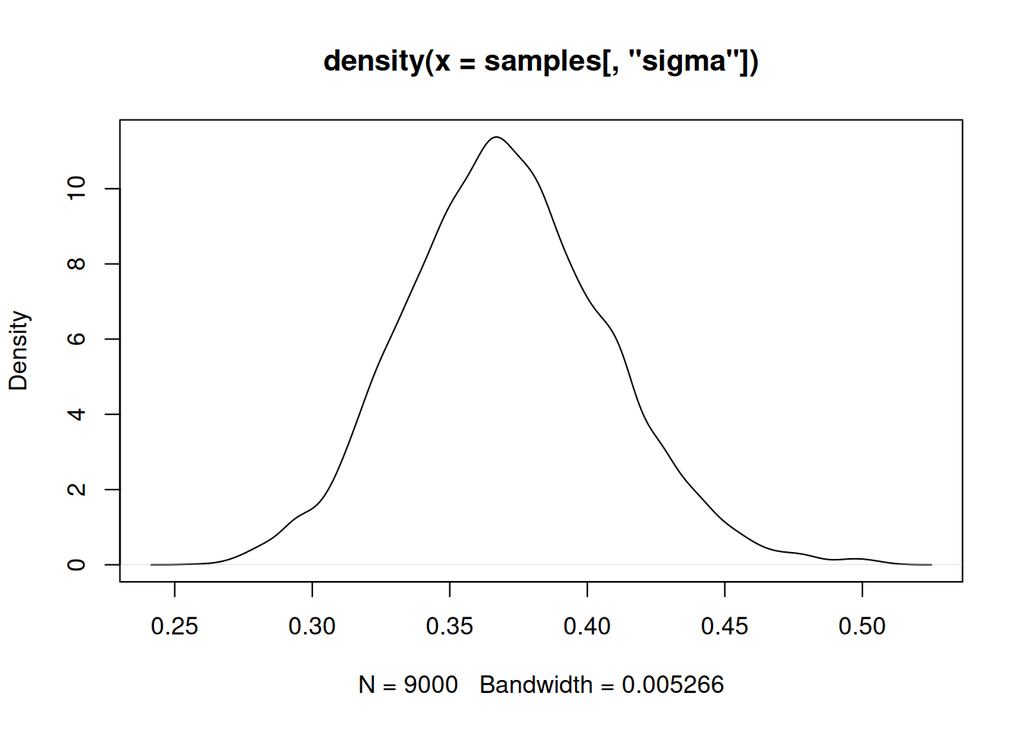

```r
plot(density(samples[,"sigma"]))
```

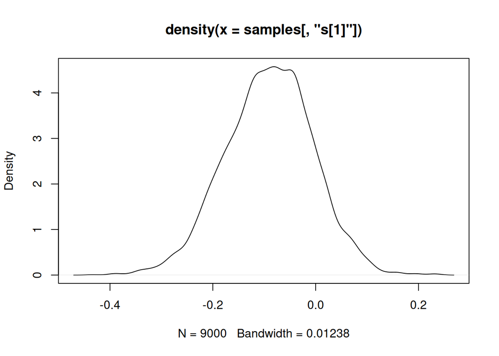

```r
plot(density(samples[,"s[1]"]))
```

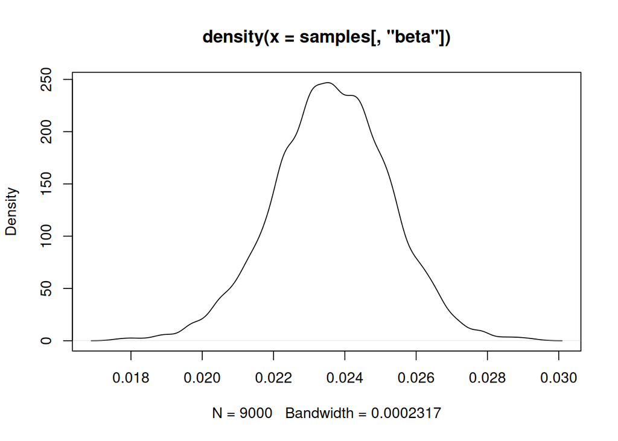

```r
plot(density(samples[,"beta"]))
```

In some cases, MCMC mixing in CAR models (particularly when considering the CAR hyperparameter(s)) can be slow, and considering NIMBLE’s HMC sampler (in the `nimbleHMC` package) may be worthwhile.